# Respuestas Práctica 1

#### Ejercicio 1

1. Categórica.
2. Numérica continua.
3. Numérica discreta.
4. Categórica.
5. Numérica discreta.
6. Numérica continua.
7. Numérica discreta.
8. Numérica discreta.
9. Categórica ordinal.
10. Numérica discreta.
11. Numérica discreta.
12. Categórica.
13. Categórica.
14. Categórica.
15. Categórica.
16. Numérica discreta.
17. Numérica discreta.

#### Ejercicio 2

1. $1.614.984
2. $57.769,27

#### Ejercicio 3

1. 25% por encima, 75% por debajo.
2. 50% por encima, 50% por debajo.
3. 80% por encima, 20% por debajo.
4. 16% por encima, 84% por debajo.

#### Ejercicio 4

Partimos de la primer expresión y desarrollamos el cuadrado del binomio:

$s^2=\frac{\sum_{i=1}^n(x_i-\overline{x})^2}{n-1}=\frac{\sum_{i=1}^n(x_i^2-2x_i\overline{x}+\overline{x}^2)}{n-1}=\frac{\sum_{i=1}^nx_i^2-2\overline{x}\sum_{i=1}^nx_i+\sum_{i=1}^n\overline{x}^2}{n-1}$

Extrayendo las constantes fuera de la sumatoria y aplicando la definición: $\overline{x}=\frac{\sum_{i=1}^nx_i}{n}$

$s^2=\frac{\sum_{i=1}^nx_i^2-2\overline{x}\sum_{i=1}^nx_i+n\overline{x}^2}{n-1}=$

$s^2=\frac{\sum_{i=1}^nx_i^2-2(\frac{\sum_{i=1}^nx_i}{n})\sum_{i=1}^nx_i+n(\frac{\sum_{i=1}^nx_i}{n})^2}{n-1}=$

$s^2=\frac{\sum_{i=1}^nx_i^2-2(\frac{(\sum_{i=1}^nx_i)^2}{n})+(\frac{(\sum_{i=1}^nx_i)^2}{n})}{n-1}=$

$s^2=\frac{\sum_{i=1}^nx_i^2-\frac{(\sum_{i=1}^nx_i)^2}{n}}{n-1}$

#### Ejercicio 5

1. $s^2$ = 3,123377
2. $s^2$ = 9,023333
3. $s^2$ = 9,785714

#### Ejercicio 6

1. Disminuye
2. $\overline{x}=73,6$
3. Aumenta

Demostración del ejercicio 6 c:

Con la información disponible para la muestra de 24 alumnos podemos calcular:

$\sum_{i=1}^{24}x_i$ y $\sum_{i=1}^{24}x_i^2$

Primero, utilizamos la información de la media muestral:

$\overline{x}=74$ –> $\frac{\sum_{i=1}^{24}x_i}{24}=74$ –> $\sum_{i=1}^{24}x_i=24*74=1.776$

Luego, utilizamos el dato del desvío estándar y la fórmula alternativa de la varianza:

$s^2=(8,9)^2=\frac{\sum_{i=1}^{24}x_i^2-\frac{(\sum_{i=1}^{24}x_i)^2}{24}}{24-1}=\frac{\sum_{i=1}^{24}x_i^2-\frac{1.776^2}{24}}{23}$

Despejando obtenemos:

$\sum_{i=1}^{24}x_i^2=(8,9)^2*23+\frac{1.776^2}{24}=133.245,83$

Con estos datos ya podemos calcular la varianza de la nueva muestra (25 alumnos):

$s^2=\frac{\sum_{i=1}^{25}x_i^2-\frac{(\sum_{i=1}^{25}x_i)^2}{25}}{25-1}=\frac{(\sum_{i=1}^{24}x_i^2+64^2)-\frac{(\sum_{i=1}^{24}x_i+64)^2}{25}}{24}$

$s^2=\frac{(133.245,83+64^2)-\frac{(1.776+64)^2}{25}}{24}=79,90958$

$s=\sqrt[2]{79,90958}=8,9392$

#### Ejercicio 7

1. z = 2
2. z = -3
3. z = -2
4. z = 1,667

#### Ejercicio 8

Se considera outlier cuando el valor z es menor a -3 o mayor a 3. a) Z=0,727. No es outlier. b) Z=-3,273. Outlier. c) Z=1,364. No es Outlier. d) Z=3,727. Outlier.

#### Ejercicio 9

Mediana = 167.5

Q3 = 174.25

Mínimo = 145

Máximo = 186

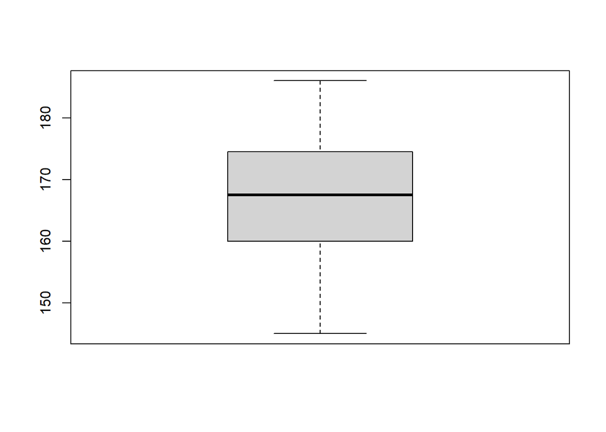

| Rango de valores | Cantidad de Alumnos |
| --- | --- |
| [140,150) | 3 |
| [150,160) | 7 |
| [160,170) | 13 |
| [170,180) | 12 |
| [180,190) | 5 |

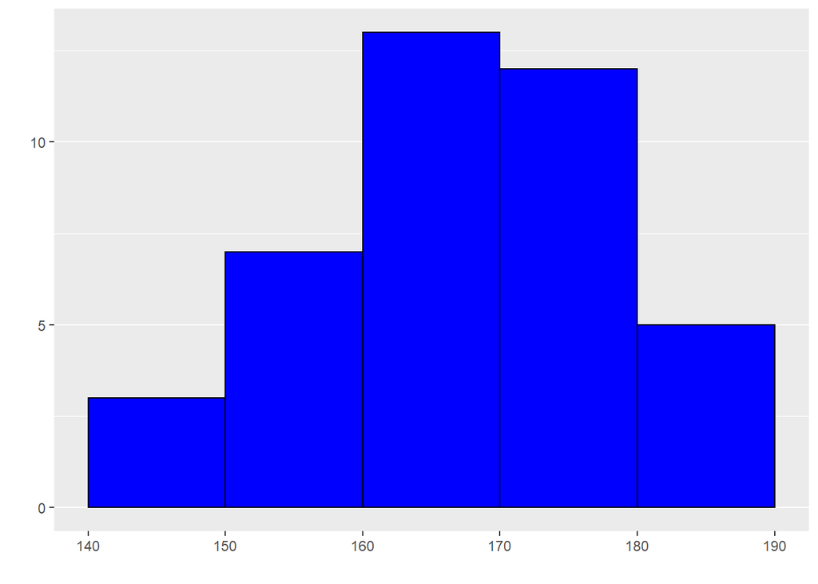

#### Ejercicio 10

Opción d.

#### Ejercicio 11

Opción d.

#### Ejercicio 12

Opción c.

#### Ejercicio 13

1. Q1 aproximadamente 5; Mediana aproximadamente 15; Q3 aproximadamente 35.
2. Mayor.

#### Ejercicio 14

1. a y 2; b y 3; c y 1.
1. Aproximadamente 1,5.
2. Aproximadamente 1 y 2.
3. Aproximadamente 1.
4. Sesgada.
5. 50% y 75%.
6. Si.

#### Ejercicio 15

En el histograma son evidentes la distribución bimodal y los valores más frecuentes. En el Box Plot son evidentes los extremos, mediana, Q1 y Q3.

#### Las respuestas a los ejercicios 16 al 36 se encuentran en un archivo excel.